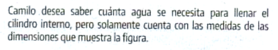

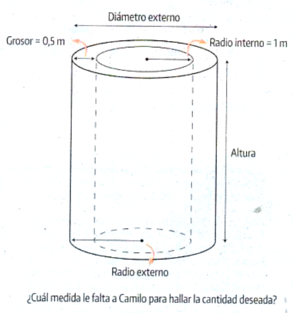

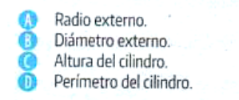

# Pregunta

Camilo desea saber cuánta agua se necesita para llenar el cilindro interno, pero solamente cuenta con las medidas de las dimensiones que muestra la figura.

Para calcular cuánta agua se necesita para llenar el cilindro interno, necesitamos conocer el volumen del espacio interior del cilindro, el cual se calcula con la fórmula del volumen de un cilindro $V = \pi r^2 h$, donde $r$ es el radio y $h$ la altura del cilindro.

1. **Determinación del radio interno**: En el problema, se indica que el radio interno es de 1 metro.
2. **Determinación de la altura del cilindro**: No se especifica directamente la altura del cilindro, pero asumiremos que es conocida para el cálculo.
3. **Cálculo del volumen**: Usando el radio interno de 1 metro, y una altura $h$ (que asumimos conocida), el volumen del cilindro se calcula como:
   $$V = \pi \times (1 \, \text{m})^2 \times h = \pi \times h \, \text{m}^3$$

Este volumen representa la cantidad de agua necesaria para llenar el cilindro hasta su altura $h$.

### **Solución Completa**

#### **Paso 1: Identificar las dimensiones conocidas del cilindro**

Conocemos el radio interno del cilindro, que es de 1 metro.

#### **Paso 2: Aplicar la fórmula del volumen de un cilindro**

Utilizamos la fórmula del volumen $V = \pi r^2 h$, sustituyendo $r = 1 \text{ m}$ y $h$ (conocida).

#### **Respuesta Final**

El volumen de agua necesaria para llenar el cilindro es $\pi h \text{ m}^3$, donde $h$ es la altura del cilindro.

### **Concepto Clave**

**Volumen del cilindro**: El volumen $V$ de un cilindro se calcula como el producto del área de la base circular (que es $\pi r^2$) por la altura $h$ del cilindro.

### **Conceptos y ejemplos relacionados**

1. **Área de la base de un cilindro**: Área = $\pi r^2$.
2. **Perímetro de la base de un cilindro**: Perímetro = $2\pi r$.
3. **Ejemplo relacionado**: Si un cilindro tiene un radio de 3 metros y una altura de 5 metros, ¿cuál es su volumen? $V = \pi \times 3^2 \times 5 = 45\pi \text{ m}^3$.

### **¿Cuál es la opción correcta?**

Para determinar cuál es la opción correcta, necesitamos analizar cuál de las opciones dadas es la más relevante para calcular el volumen del cilindro interno con la información disponible en el problema. Las opciones son:

A. Radio externo. B. Diámetro externo. C. Altura del cilindro. D. Perímetro del cilindro.

El cálculo del volumen de un cilindro se realiza mediante la fórmula $V = \pi r^2 h$, donde $r$ es el radio y $h$ es la altura. Para el cilindro interno, el radio interno es conocido (1 metro), pero necesitamos la altura del cilindro para completar el cálculo del volumen.

**La opción correcta es:** C. Altura del cilindro.

Esta es la medida crucial faltante que necesitamos para calcular el volumen de agua que el cilindro puede contener, dado que el radio interno ya es conocido.

## **Retroalimentación Saber ICFES**

### Análisis del Problema

Para resolver este problema, debemos determinar qué medidas son necesarias para calcular la cantidad de agua que se necesita para llenar el cilindro interno.

El volumen del cilindro interno se puede calcular utilizando la fórmula del volumen de un cilindro:

$$V = \pi r^2 h$$

donde $r$ es el radio del cilindro y $h$ es la altura del cilindro.

### Información Proporcionada

De la figura y la descripción:

- El radio interno del cilindro es $1 \, \text{m}$.
- El grosor del cilindro es $0.5 \, \text{m}$.
- No se proporciona directamente la altura del cilindro.

### Determinación de las Opciones

Vamos a analizar cada opción para determinar cuál es la necesaria para calcular el volumen del cilindro interno.

1. **Opción A: Radio externo.**
   - El radio externo se puede calcular sumando el grosor al radio interno: $r_{externo} = r_{interno} + \text{grosor}$.
   - En este caso, $r_{externo} = 1 \, \text{m} + 0.5 \, \text{m} = 1.5 \, \text{m}$.
   - **No es necesaria esta medida para calcular el volumen del cilindro interno.**
2. **Opción B: Diámetro externo.**
   - El diámetro externo se puede calcular multiplicando el radio externo por 2: $d_{externo} = 2 \times r_{externo}$.
   - **No es necesaria esta medida para calcular el volumen del cilindro interno.**
3. **Opción C: Altura del cilindro.**
   - La altura del cilindro es un componente crucial en la fórmula del volumen: $V = \pi r^2 h$.
   - **Esta medida es necesaria para calcular el volumen del cilindro interno.**
4. **Opción D: Perímetro del cilindro.**
   - El perímetro de la base del cilindro (circunferencia) se calcula con la fórmula $P = 2 \pi r$.
   - **No es necesaria esta medida para calcular el volumen del cilindro interno.**

### Retroalimentación

**Nivel de Desempeño:** Nivel 2 - **Justificación:** El problema requiere la identificación de las medidas necesarias para calcular el volumen del cilindro, lo cual implica comprensión básica de fórmulas geométricas.

**Competencia:** Formulación y ejecución - **Justificación:** El problema implica identificar las dimensiones correctas para aplicar una fórmula matemática.

**Componente:** Geometría - **Justificación:** Se relaciona con el cálculo de volúmenes de figuras geométricas.

**Tipo de Pensamiento:** Espacial-métrico - **Justificación:** Implica entender las dimensiones y relaciones métricas del cilindro.

**Estándar Asociado y Categoría:** - **Estándar Asociado:** Utiliza propiedades y fórmulas geométricas para resolver problemas. - **Categoría:** Contenido no genérico - **Justificación:** Aplica conocimientos específicos de geometría.

**Situaciones o Contexto:** Contexto cotidiano - **Justificación:** Se enmarca en una situación práctica de uso de un cilindro.

**Problema Analizado:** - **Habilidad o Conocimiento Evaluado:** Cálculo de volúmenes utilizando fórmulas geométricas. - **Justificación:** Evalúa la capacidad de identificar las dimensiones necesarias para aplicar una fórmula geométrica.

**Eje Axial Disciplinar:** Geometría - **Justificación:** Se centra en la comprensión y manipulación de figuras geométricas tridimensionales.

### ¿Qué Evalúa?

El problema evalúa la habilidad para identificar las dimensiones necesarias y aplicar fórmulas geométricas para calcular volúmenes.

### Respuesta Correcta

**La respuesta correcta es:** C. Altura del cilindro.

### Justificación de la Respuesta Correcta

Para calcular el volumen del cilindro interno, necesitamos la altura del cilindro. El radio interno ya se proporciona, pero la altura es la medida crucial faltante.

### Motivos que Llevan a Escoger Cada Una de las Opciones Incorrectas

- **Opción A (Radio externo):** No es necesario para calcular el volumen interno.
- **Opción B (Diámetro externo):** No es necesario para el volumen del cilindro interno.
- **Opción D (Perímetro del cilindro):** No es útil para calcular el volumen del cilindro interno.

### Desde Qué Nivel (Grado) de Enseñanza se Puede Aplicar Este Ejercicio

**Nivel Educativo:** Grado 9 o 10 - **Justificación:** A este nivel, los estudiantes deberían tener conocimientos suficientes de geometría y volúmenes de cuerpos sólidos.